# Walking you through irpanels

`irpanels` can be downloaded as follows:

```r
devtools::install_github("sirpudika/irpanels")
```

```r
library(irpanels)
library(tidyverse)
```

Currently, `irpanels` offers the following functions:

```
#>  [1] "%>%"               "cb_mistable"       "cb_page"
#>  [4] "cb_pages"          "cb_sumplot"        "cb_sumplot_mcq"
#>  [7] "cb_sumtab"         "cb_table"          "eda_crosstable"
#> [10] "eda_freqtable"     "helper_percentage" "n_par"
#> [13] "plot_bar_h"        "plot_bar_v"        "plot_groupbar_h"
#> [16] "plot_groupbar_v"   "plot_multiple_h"   "plot_rank_v"
#> [19] "sep_palette"       "sep_palettes"      "share_dk"
#> [22] "theme_sep"
```

The prefixes indicate the step in the workflow. The functions beginning with `cb` simplify creating the codebook. The `eda` functions are for exploratory data analysis. The functions starting with `plot`, in turn, help to visualize the data. Finally, there are some additional helper functions.

FYI: The datasets used here are not publicly accessible for data protection reasons. However, they can be requested [here](https://istp.ethz.ch/research/sep.html).

```r
load("upanel_w5.RData")
load("upanel_w8.RData")
```

## Frequency Tables

Very often we need to know the relative frequencies of the responses to a survey item. `eda_freqtable` helps to get these numbers quickly. By default, the logical operator is `rm.dk = FALSE`, i.e. the relative proportion of “Don’t know” responses is included.

```r
eda_freqtable(w5, item = w5_q27)
```

```
#> Relative frequencies:
#>    -8     1     2     3     4     5     6     7
#>  6.37  0.90  2.60 10.98 43.55 18.76 12.11  4.72
```

```r
eda_freqtable(w5, item = w5_q27, rm.dk = T)
```

```
#> Relative frequencies:
#>     1     2     3     4     5     6     7
#>  0.97  2.78 11.73 46.51 20.03 12.94  5.04
```

To calculate the relative frequencies based on two variables, you can use `eda_crosstable`. The two variables must be specified as characters in a vector. Here, too, “Don’t knows” can be included/excluded via the logical operator `rm.dk`.

```r
eda_crosstable(w5, items = c("w5_q2", "w5_q11"))
```

```
#>      w5_q11
#> w5_q2    -8     1     2     3     4     5
#>     1  7.00  3.73 10.01 16.03 11.27  1.66
#>     2  4.71  2.87  6.83 13.65 17.56  4.67
```

```r
eda_crosstable(w5, items = c("w5_q2", "w5_q11"), rm.dk = TRUE)
```

```
#>      w5_q11
#> w5_q2     1     2     3     4     5
#>     1  4.22 11.34 18.16 12.77  1.88
#>     2  3.26  7.73 15.46 19.89  5.29
```

## Visualizations

Six plot functions are currently available: `plot_bar_v`, `plot_bar_h`, `plot_groupbar_v`, `plot_groupbar_h`, `plot_multiple_h` and `plot_rank_v`. As the respective names imply, the first two functions are used to visualize one variable; the second two allow visualization with a grouping variable; the fifth function plots multiple subitems from the same question (optionally by grouping and/or treatment variables); and the last function visualizes rankings (optionally by grouping and/or treatment variables). All functions are available in German (default) or in English (set `lang = "EN"`). All functions moreover have the argument `weights`, which allows to weight the output by survey weights (default: no weighting).

### *plot_bar_v* / *plot_bar_h*

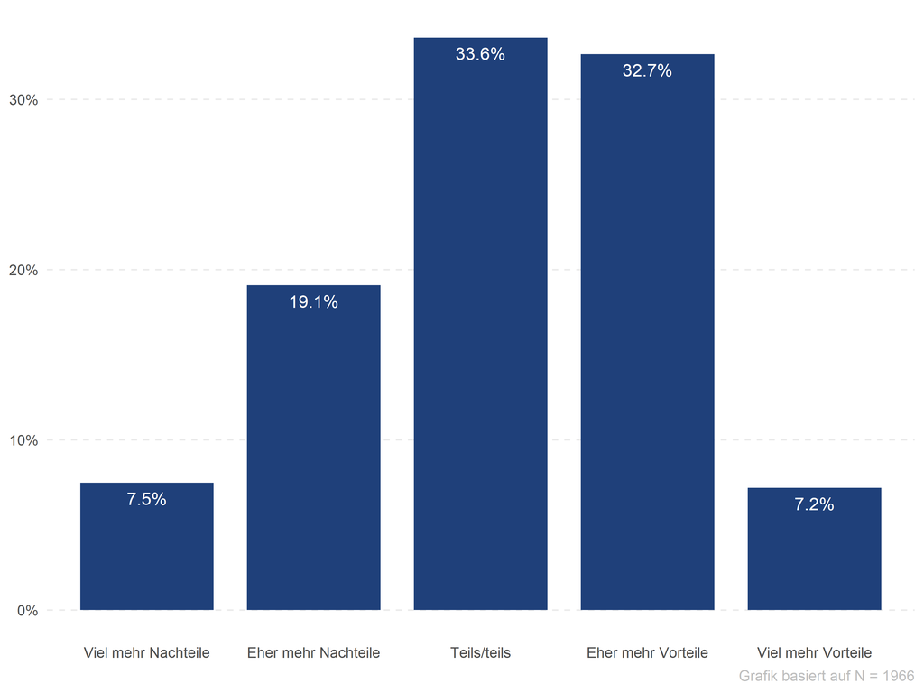

```r
plot_bar_v(w5, item = w5_q11, textsize = 11)
```

By specifying the argument `question`, you can add the question in the caption.

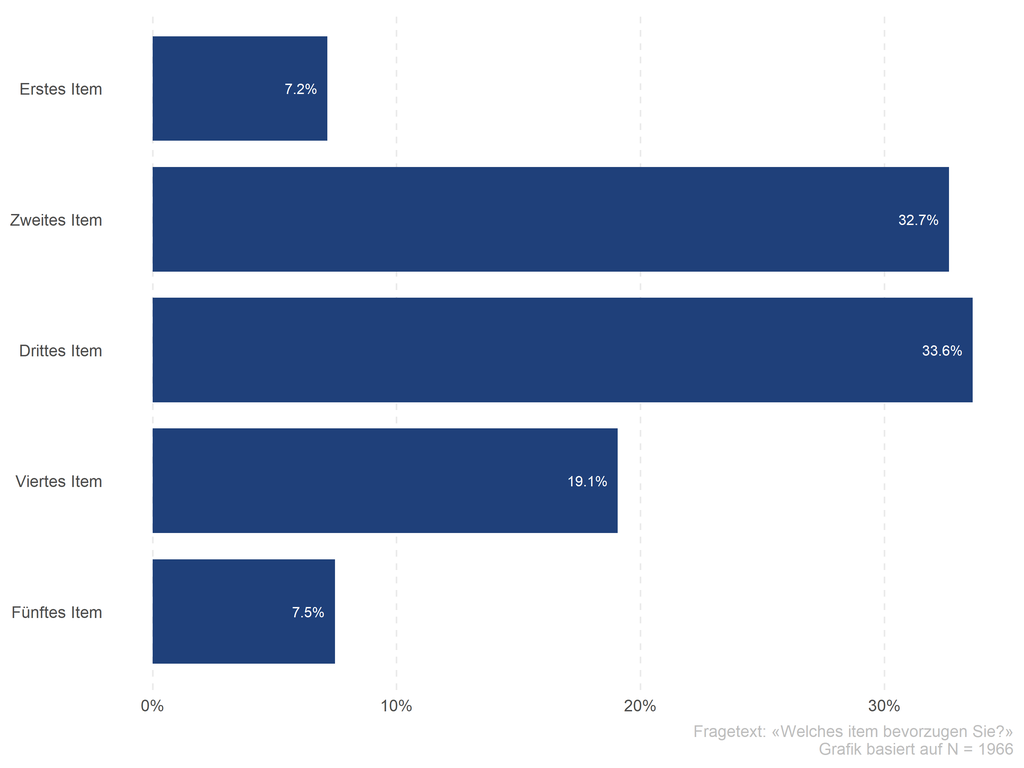

```r
plot_bar_h(w5, item = w5_q11, question = "Welches item bevorzugen Sie?") +
  scale_x_discrete(labels = rev(c("Erstes Item", "Zweites Item", "Drittes Item", "Viertes Item", "Fünftes Item")))
```

### *plot_groupbar_v* / *plot_groupbar_h*

Before moving on to the visualizations of grouped variables, it’s worth highlighting the helper function `sep_palette"`. This function allows users to choose from a range of official ETH colour palettes. Available are the following palettes:

`"Standard", "Darkblues", "Greens", "Lightblues", "Lightgreens", "Pinks", "BluePink"`

You can select the palette of your choice by either saving it as an object or directly calling it in the plot function.

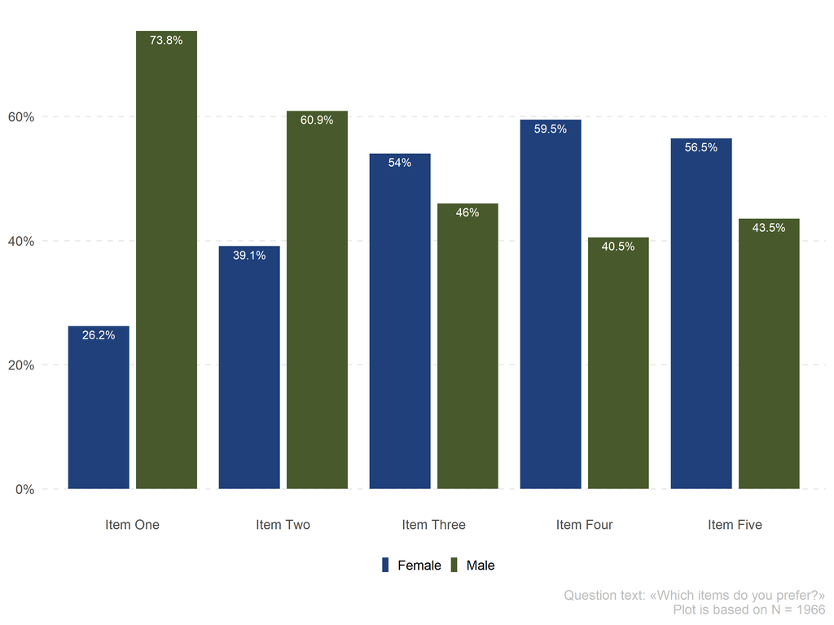

```r
plot_groupbar_v(w5, item = w5_q11, by = w5_q2, lang = "EN",
                question = "Which items do you prefer?",
                labels = c("Female", "Male"), values = sep_palette("Standard")) +
  scale_x_discrete(labels = c("Item One", "Item Two", "Item Three", "Item Four", "Item Five"))
```

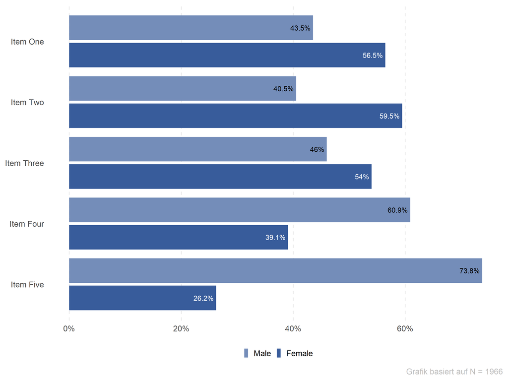

```r
plot_groupbar_h(w5, item = w5_q11, by = w5_q2,
                labels = c("Female", "Male"), values = sep_palette("Darkblues")) +
  scale_x_discrete(labels = rev(c("Item One", "Item Two", "Item Three", "Item Four", "Item Five")))
```

The barposition of both groupbar functions can be changed from its default “dodge” to e.g. “stack”:

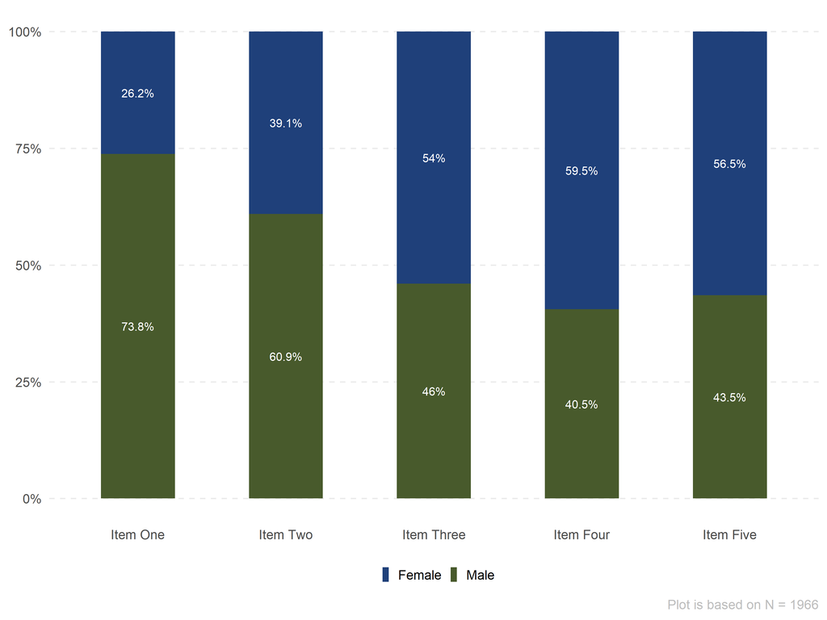

```r
plot_groupbar_v(w5, item = w5_q11, by = w5_q2, lang = "EN", barposition = "stack",
                labels = c("Female", "Male"), values = sep_palette("Standard")) +
  scale_x_discrete(labels = c("Item One", "Item Two", "Item Three", "Item Four", "Item Five"))
```

### *plot_multiple_h*

The plot function `plot_multiple_h` depicts several items from the same question in one plot. The argument `item` takes as input a vector of variables.

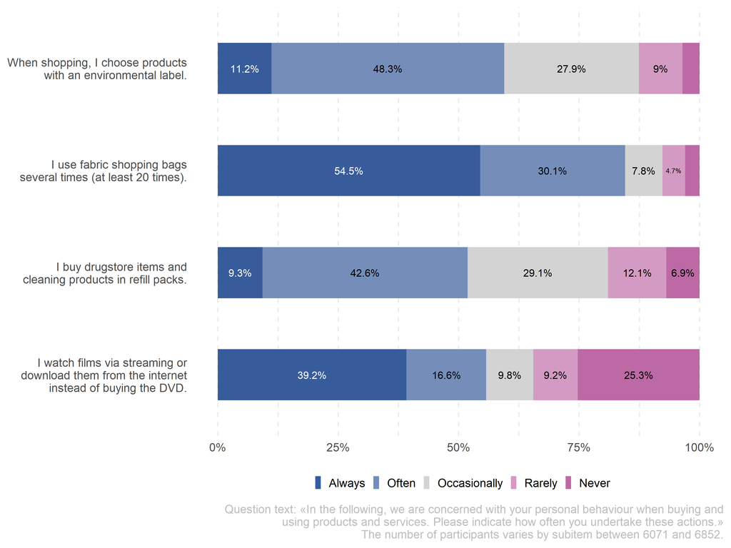

```r
item_labels <- c("When shopping, I choose products\nwith an environmental label.", "I use fabric shopping bags\nseveral times (at least 20 times).", "I buy drugstore items and\ncleaning products in refill packs.",
                 "I watch films via streaming or\ndownload them from the internet\ninstead of buying the DVD.")
question <- "In the following, we are concerned with your personal behaviour when buying and\nusing products and services. Please indicate how often you undertake these actions."

plot_multiple_h(w8, item = paste0("w8_q6x", 1:4), barwidth = 0.5, lang = "EN",
                item_labels = item_labels, question = question,
                values = sep_palettes$BluePink,
                labels = c("Never", "Rarely", "Occasionally", "Often", "Always"))
```

If you do not specify `item_labels` or `question` within the function call, the function will look whether this information is available in the global environment. Technically, you thus do not necessarily need to specify it in the function itself, as long as you define it beforehand. However, it is recommended to specify it within the function to avoid mistakes. If `question` is specified neither in the function call nor in the global environment, no question is printed. If `item_labels` is specified neither in the function call nor in the global environment, an error is returned.

The plot can also distinct by grouping variable and/or treatment variable. In order to achieve this, the argument `by` and/or `treat` must be defined.

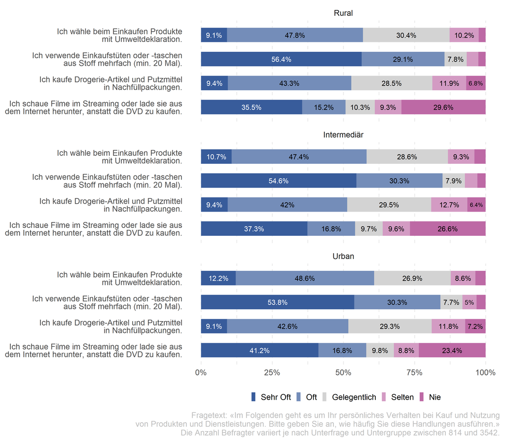

```r
items <- c("Ich wähle beim Einkaufen Produkte\nmit Umweltdeklaration.", "Ich verwende Einkaufstüten oder -taschen\naus Stoff mehrfach (min. 20 Mal).",
           "Ich kaufe Drogerie-Artikel und Putzmittel\nin Nachfüllpackungen.", "Ich schaue Filme im Streaming oder lade sie aus\ndem Internet herunter, anstatt die DVD zu kaufen.")
q <- "Im Folgenden geht es um Ihr persönliches Verhalten bei Kauf und Nutzung\nvon Produkten und Dienstleistungen. Bitte geben Sie an, wie häufig Sie diese Handlungen ausführen."

plot_multiple_h(w8, item = paste0("w8_q6x", 1:4), by = rurality,
                item_labels = items, question = q,
                values = sep_palettes$BluePink,
                labels = c("Nie", "Selten", "Gelegentlich", "Oft", "Sehr Oft")) +
  theme(axis.text.y = element_text(lineheight = 0.8)) #decrease spacing between item label lines
```

Moreover, arguments determining barwidth, size of percentage text as well as percentage and legend positions can be specified. When grouping by grouping or treatment variable, the argument `ncol.wrap` furthermore allows to specify how many columns the facets should be organised in (above and default: 1).

### *plot_rank_v*

As the name implies, this plot functions visualizes rankings. The argument `n.items` sets the number of items per rank. By default, all items are shown. If the argument is set to fewer items (example below: 4 items), the most prominent items for each rank are visualized. The items are ordered according to their order in rank 1, with the most-often picked choice at the bottom. As with `plot_multiple_h`, the function takes the information on `item_labels` and `question` from the global environment if it is not specified within the function call; but it is recommended to specify the information within the function call.

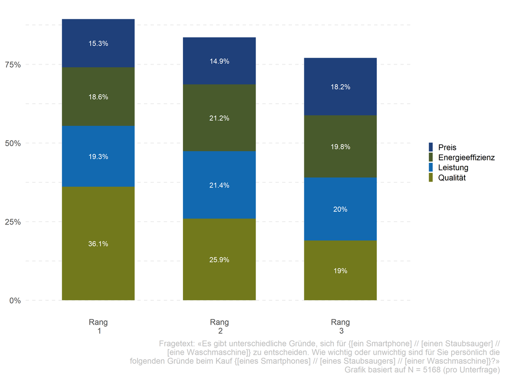

```r
items <- c("Preis", "Qualität", "Technische Neuheit", "Aussehen", "Leistung",
           "Energieeffizienz", "Umweltbelastung\nbei Herstellung")
q <- "Es gibt unterschiedliche Gründe, sich für {[ein Smartphone] // [einen Staubsauger] //\n[eine Waschmaschine]} zu entscheiden. Wie wichtig oder unwichtig sind für Sie persönlich die\nfolgenden Gründe beim Kauf {[eines Smartphones] // [eines Staubsaugers] // [einer Waschmaschine]}?"

plot_rank_v(w8, item = paste0("w8_q16ax", 1:3), n.items = 4,
            item_labels = items, question = q,
            values = sep_palette("Standard"))
```

Beyond `n.items`, the same arguments can be set for this plot function as for `plot_multiple_h`. It can also distinct by grouping and/or treatment variable.

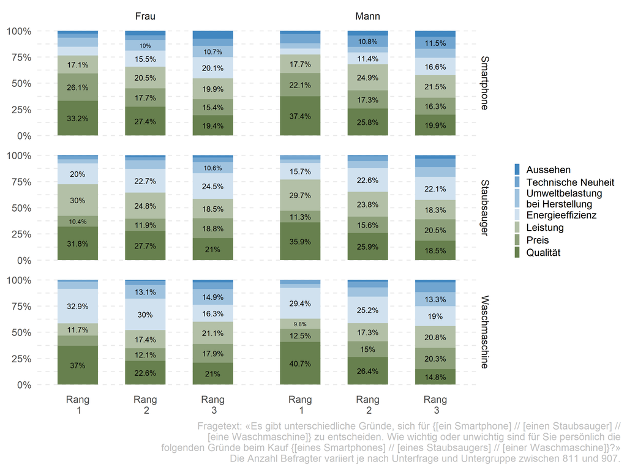

```r
items <- c("Preis", "Qualität", "Technische Neuheit", "Aussehen", "Leistung",
           "Energieeffizienz", "Umweltbelastung\nbei Herstellung")
q <- "Es gibt unterschiedliche Gründe, sich für {[ein Smartphone] // [einen Staubsauger] //\n[eine Waschmaschine]} zu entscheiden. Wie wichtig oder unwichtig sind für Sie persönlich die\nfolgenden Gründe beim Kauf {[eines Smartphones] // [eines Staubsaugers] // [einer Waschmaschine]}?"

plot_rank_v(w8, item = paste0("w8_q16ax", 1:3), textsize = 7,
            by = gender, treat = w8_treat_repair,
            item_labels = items, question = q,
            values = c(sep_palettes$Lightblues[1:4], rev(sep_palettes$Greens[1:3]))) +
  theme(panel.spacing.y = unit(0.3, "cm")) #increase space between facet rows
```